# Discussion8

Jing Lyu

3/1/2023

#### Two-way ANOVA with random effects

Consider a balanced design:

$$Y_{ijk} = \mu_{ij} +\epsilon_{ijk}=\mu_{\cdot\cdot} + \alpha_i+\beta_j + (\alpha\beta)_{ij}+\epsilon_{ijk},k=1,\ldots, n, j=1,\ldots, b, i=1,\ldots, a$$
where $\alpha_i \sim N(0,\sigma_{\alpha}^2)$, $\beta_j \sim N(0,\sigma_{\beta}^2)$, $(\alpha\beta)_{ij} \sim N(0,\sigma^2_{\alpha\beta})$, $\epsilon_{ijk} \sim_{iid} N(0,\sigma^2)$, and all random variables are mutually independent.

We have the following properties:

1. $\mathbb{E}[Y_{ijk}]=\mu_{\cdot\cdot}$.
2. ${\rm var}(Y_{ijk})=\sigma_{\alpha}^2+\sigma_{\beta}^2+\sigma_{\alpha\beta}^2+\sigma^2$.
3. ${\rm cov}(Y_{ijk},Y_{ijk'})=\sigma_{\alpha}^2+\sigma_{\beta}^2+\sigma_{\alpha\beta}^2$ for $k\neq k'$.
4. ${\rm cov}(Y_{ijk},Y_{ij'k'})=\sigma_{\alpha}^2$ for $j\neq j'$.
5. ${\rm cov}(Y_{ijk},Y_{i'jk'})=\sigma_{\beta}^2$ for $i\neq i'$.
6. ${\rm cov}(Y_{ijk},Y_{i'j'k'})=0$ when no indices are equal.

$\mathbb{E}[{\rm MSA}]=\sigma^2+n\sigma^2_{\alpha\beta}+bn\sigma^2_{\alpha}, \mathbb{E}[{\rm MSB}]=\sigma^2+n\sigma^2_{\alpha\beta}+an\sigma^2_{\beta},\\ \mathbb{E}[{\rm MSAB}]=\sigma^2+n\sigma^2_{\alpha\beta}, \mathbb{E}[{\rm MSE}]=\sigma^2$

then

$\mathbb{E}[{\rm MSAB}]- \mathbb{E}[{\rm MSE}]=n\sigma^2_{\alpha\beta}, \mathbb{E}[{\rm MSA}]-\mathbb{E}[{\rm MSAB}]=bn \sigma_{\alpha}^2, \mathbb{E}[{\rm MSB}]-\mathbb{E}[{\rm MSAB}]=an \sigma_{\beta}^2$.

Test statistics:

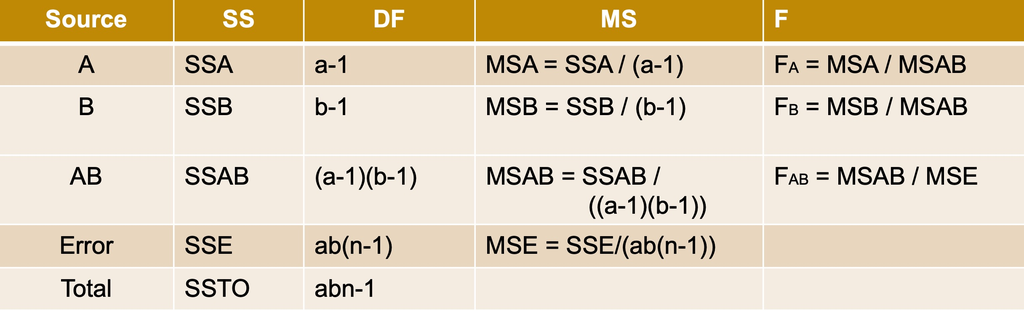

For this section, we consider a dataset from online resources. Five employees are randomly selected from a company. Six batches of source material are randomly selected from the production process. The material from each batch was divided into 15 pieces. They were randomized to the different employees such that each employee would have three test specimens from each batch. The response was the corresponding quality score.

```r
book.url <- "https://stat.ethz.ch/~meier/teaching/book-anova"
quality <- readRDS(url(file.path(book.url, "data/quality.rds")))
str(quality)
```

```
## 'data.frame':    90 obs. of  3 variables:
##  $ employee: Factor w/ 5 levels "1","2","3","4",..: 1 1 1 1 1 1 1 1 1 1 ...
##  $ batch   : Factor w/ 6 levels "B1","B2","B3",..: 1 1 1 2 2 2 3 3 3 4 ...
##  $ score   : num  27.4 27.8 27.3 25.5 25.5 26.4 26.9 26.3 25.1 25.6 ...
```

```r
head(quality)
```

```
##   employee batch score
## 1        1    B1  27.4
## 2        1    B1  27.8
## 3        1    B1  27.3
## 4        1    B2  25.5
## 5        1    B2  25.5
## 6        1    B2  26.4
```

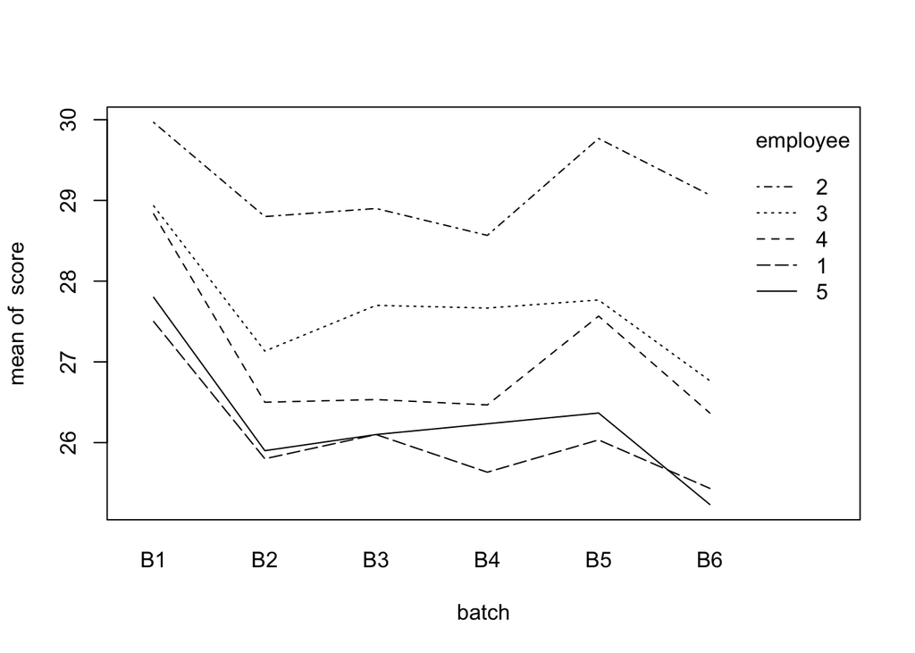

```r
with(quality, interaction.plot(x.factor = batch, trace.factor = employee, response = score))
```

It seems variation exists between employees and between batches. Interaction effect is not obvious.

##### Model fitting

Consider random main effects and random interaction effect:

```r
library(lme4)
fit.quality = lmer(score ~ (1 | employee) + (1 | batch) +
                      (1 | employee:batch), data = quality)
summary(fit.quality)
```

```
## Linear mixed model fit by REML ['lmerMod']
## Formula: score ~ (1 | employee) + (1 | batch) + (1 | employee:batch)
##    Data: quality
##
## REML criterion at convergence: 167.5
##
## Scaled residuals:
##     Min      1Q  Median      3Q     Max
## -1.8144 -0.5933 -0.1190  0.7073  2.8565
##
## Random effects:
##  Groups         Name        Variance Std.Dev.
##  employee:batch (Intercept) 0.02349  0.1533
##  batch          (Intercept) 0.51764  0.7195
##  employee       (Intercept) 1.54473  1.2429
##  Residual                   0.22655  0.4760
## Number of obs: 90, groups:  employee:batch, 30; batch, 6; employee, 5
##
## Fixed effects:
##             Estimate Std. Error t value
## (Intercept)  27.2478     0.6313   43.16
```

From the output, we have $\widehat{\sigma_\alpha}^2=1.54$(employee), $\widehat{\sigma_\beta}^2=0.52$(batch), $\widehat{\sigma_{\alpha\beta}}^2=0.02$(interaction), and $\widehat{\sigma}^2=0.23$(error).

The largest contribution to the total variance is the variance among employees which contributes to $1.54/(1.54+0.52+0.02+0.23)\approx67\%$ of the total variance.

#### Mixed effects model

Consider a balanced design:

$$Y_{ijk}=\mu+\alpha_i+\beta_j+(\alpha\beta)_{ij}+\epsilon_{ijk},k=1,\ldots, n, j=1,\ldots, b, i=1,\ldots, a$$
where

$\alpha_i$ is the fixed effect with constraints $\sum\alpha_i=0$.

$\beta_j$ is the random effect following i.i.d. $N(0,\sigma_{\beta}^2)$.

$(\alpha\beta)_{ij}$ is the corresponding random interaction effect with constraints $\sum_i(\alpha\beta)_{ij}=0$ for any $j$. $(\alpha\beta)_{ij}\sim N(0,(1-1/a)\sigma^2_{\alpha\beta})$, ${\rm cov}( (\alpha\beta)_{ij}, (\alpha\beta)_{i'j})= -\sigma^2_{\alpha\beta}/a$, ${\rm cov}( (\alpha\beta)_{ij}, (\alpha\beta)_{i'j'})=0$, if $i\neq i'$ and $j\neq j'$.

$\{\epsilon_{ijk}\}$ are i.i.d. $N(0,\sigma^2)$. $\{ \beta_j\}$, $\{(\alpha\beta)_{ij}\}$, $\{\epsilon_{ijk} \}$ are mutually independent.

We have the following properties:

1. $\mathbb{E}[Y_{ijk}]=\mu_{\cdot\cdot}+\alpha_i$
2. ${\rm var}(Y_{ijk})=\sigma_{\beta}^2+(1-1/a)\sigma_{\alpha\beta}^2+\sigma^2$.
3. ${\rm cov}(Y_{ijk},Y_{ijk'})=\sigma_{\beta}^2+(1-1/a)\sigma_{\alpha\beta}^2$ for $k\neq k'$.
4. ${\rm cov}(Y_{ijk},Y_{ij'k'})=0$ for $j\neq j'$.
5. ${\rm cov}(Y_{ijk},Y_{i'jk'})=\sigma_{\beta}^2-\sigma_{\alpha\beta}^2/a$ for $i\neq i'$.
6. ${\rm cov}(Y_{ijk},Y_{i'j'k'})=0$ when no indices are equal.

$\mathbb{E}[{\rm MSA}]=\sigma^2+nb\frac{\sum\alpha_i^2}{a-1}+n\sigma^2_{\alpha\beta}, \mathbb{E}[{\rm MSB}]=\sigma^2+an\sigma^2_{\beta}, \\ \mathbb{E}[{\rm MSAB}]=\sigma^2+n\sigma^2_{\alpha\beta}, \mathbb{E}[{\rm MSE}]=\sigma^2$

then

$\mathbb{E}[{\rm MSAB}]- \mathbb{E}[{\rm MSE}]=n\sigma^2_{\alpha\beta}, \mathbb{E}[{\rm MSA}]-\mathbb{E}[{\rm MSAB}]=nb\frac{\sum\alpha_i^2}{a-1}, \mathbb{E}[{\rm MSB}]-\mathbb{E}[{\rm MSE}]=an \sigma_{\beta}^2$

Test statistics:

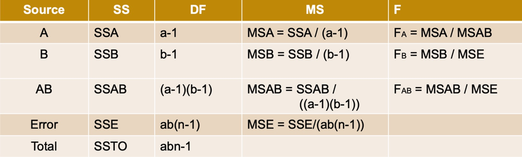

For this section, we use `Machines` dataset from `nlme` package. It contains experiment results of three brands of machines. Six workers were randomly chosen among the employees of a factory to operate each machine three times. Productivity score is considered as the response variable.

```r
data("Machines", package = "nlme")
class(Machines) <- "data.frame"
Machines[, "Worker"] <- factor(Machines[, "Worker"], levels = 1:6,
                               ordered = FALSE)
str(Machines, give.attr = FALSE) ## give.attr to shorten output
```

```
## 'data.frame':    54 obs. of  3 variables:
##  $ Worker : Factor w/ 6 levels "1","2","3","4",..: 1 1 1 2 2 2 3 3 3 4 ...
##  $ Machine: Factor w/ 3 levels "A","B","C": 1 1 1 1 1 1 1 1 1 1 ...
##  $ score  : num  52 52.8 53.1 51.8 52.8 53.1 60 60.2 58.4 51.1 ...
```

##### Visualization

We use the mean of scores for each combination of worker and machine to visualize the data.

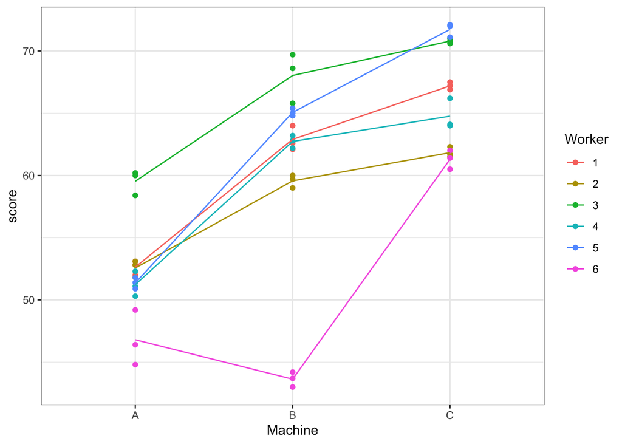

```r
library(ggplot2)
ggplot(Machines, aes(x = Machine, y = score, group = Worker, col = Worker)) +
  geom_point() + stat_summary(fun = mean, geom = "line") + theme_bw()
```

We can see the difference of scores among machines. Machine C has the largest productivity in general. We can also observe different profiles across workers. Most workers show similar profiles except that worker 6 performs badly on machine B.

Suppose the interest is to study the specific machines, then machine is regarded as a fixed effect. Each worker is randomly selected from the factory and has its own random deviation. We use mixed effects model to make inference.

##### Model fitting

```r
fit.machines <- lmer(score ~ Machine + (1 | Worker) +
                       (1 | Worker:Machine), data = Machines)
anova(fit.machines)
```

```
## Analysis of Variance Table
##         npar Sum Sq Mean Sq F value
## Machine    2 38.051  19.025  20.576
```

`lme4` does not calculate p-values for the fixed effects, so the package `lmerTest` was used instead.

`contr.treatment` contrasts each level with the baseline level (reference group).

`contr.poly` returns contrasts based on orthogonal polynomials.

```r
options(contrasts = c("contr.treatment", "contr.poly"))
#library(lmerTest)
fit.machines <- lmerTest::lmer(score ~ Machine + (1 | Worker) +
                       (1 | Worker:Machine), data = Machines)
anova(fit.machines)
```

```
## Type III Analysis of Variance Table with Satterthwaite's method
##         Sum Sq Mean Sq NumDF DenDF F value    Pr(>F)
## Machine 38.051  19.025     2    10  20.576 0.0002855 ***
## ---
## Signif. codes:  0 '***' 0.001 '**' 0.01 '*' 0.05 '.' 0.1 ' ' 1
```

The fixed effect of machine is significant.

```r
summary(fit.machines)
```

```
## Linear mixed model fit by REML. t-tests use Satterthwaite's method [
## lmerModLmerTest]
## Formula: score ~ Machine + (1 | Worker) + (1 | Worker:Machine)
##    Data: Machines
##
## REML criterion at convergence: 215.7
##
## Scaled residuals:
##      Min       1Q   Median       3Q      Max
## -2.26959 -0.54847 -0.01071  0.43937  2.54006
##
## Random effects:
##  Groups         Name        Variance Std.Dev.
##  Worker:Machine (Intercept) 13.9095  3.7295
##  Worker         (Intercept) 22.8584  4.7811
##  Residual                    0.9246  0.9616
## Number of obs: 54, groups:  Worker:Machine, 18; Worker, 6
##
## Fixed effects:
##             Estimate Std. Error     df t value Pr(>|t|)
## (Intercept)   52.356      2.486  8.522  21.062 1.20e-08 ***
## MachineB       7.967      2.177 10.000   3.660  0.00439 **
## MachineC      13.917      2.177 10.000   6.393 7.91e-05 ***
## ---
## Signif. codes:  0 '***' 0.001 '**' 0.01 '*' 0.05 '.' 0.1 ' ' 1
##
## Correlation of Fixed Effects:
##          (Intr) MachnB
## MachineB -0.438
## MachineC -0.438  0.500
```

Machine A is considered as the reference gorup. The productivity score on machine B is on average 7.97 units larger than on machine A.

### References

https://stat.ethz.ch/~meier/teaching/anova/random-and-mixed-effects-models.html#eq:cell-means-random